# Stat 579 - Homework #1

9/6/2018

## Swiss Banknotes

1. Download the RMarkdown file with these homework instructions to use as a template for your work. Make sure to replace “Your Name” in the YAML with your name.
2. The R package `alr3` contains a data set called `banknote`, consisting of (physical) measurements on 200 Swiss bank notes, 100 of which are genuine, while the other half is counterfeit. Load this data set (you might have to install the package) using the code below. Also run the cryptic third line - it will make your life a lot easier for the rest of the homework. This turns variable Y explicitly into a factor variable, i.e. makes it discrete. We will discuss this in the course material later in more detail.

```r
# install.packages("alr3")
library(alr3) # if this throws an error of the form 'there is no package called alr3', uncomment the line above, run it once, then comment the line out again and run the code chunk again.
data(banknote)
banknote$Y <- factor(banknote$Y)
```

3. Use one of our object inspecting functions and interpret the result in the data that you see.

```r
str(banknote)
```

```
## 'data.frame':    200 obs. of  7 variables:
##  $ Length  : num  215 215 215 215 215 ...
##  $ Left    : num  131 130 130 130 130 ...
##  $ Right   : num  131 130 130 130 130 ...
##  $ Bottom  : num  9 8.1 8.7 7.5 10.4 9 7.9 7.2 8.2 9.2 ...
##  $ Top     : num  9.7 9.5 9.6 10.4 7.7 10.1 9.6 10.7 11 10 ...
##  $ Diagonal: num  141 142 142 142 142 ...
##  $ Y       : Factor w/ 2 levels "0","1": 1 1 1 1 1 1 1 1 1 1 ...
```

There are six different measurements for each of the 200 banknotes, the length, left side, right side, bottom, top and diagonal. There is also a factor indicating whether the note is genuine or not.

4. Use the package `ggplot2` to draw a barchart of Y (0 is genuine, 1 is counterfeit). Map Y to the fill color of the barchart.

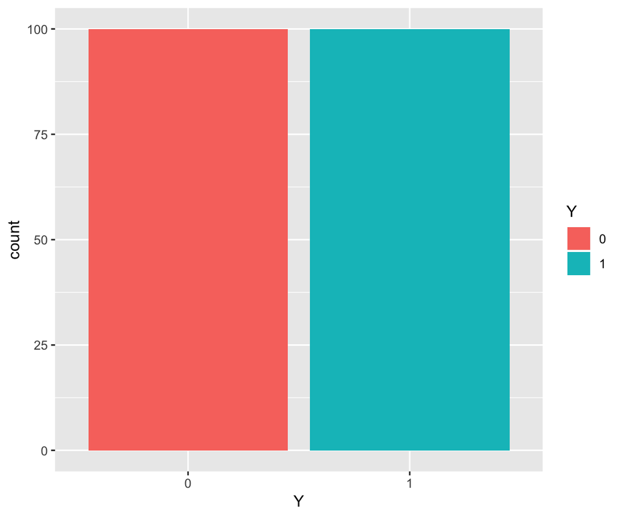

```r
library(tidyverse)
ggplot(banknote, aes(x = Y, fill = Y)) +
  geom_bar()
```

This barchart shows the number of banknotes that are counterfeit and the number that are genuine. There isn’t much intrestring about this plot, but we can see that there are the same number of each note.

5. Use the package `ggplot2` to draw a histogram of one of the variables in the dataset that shows a distinction between genuine and counterfeit banknotes. Use fill color to show this difference. Choose the binwidth such that there are no gaps in the middle range of the histogram.

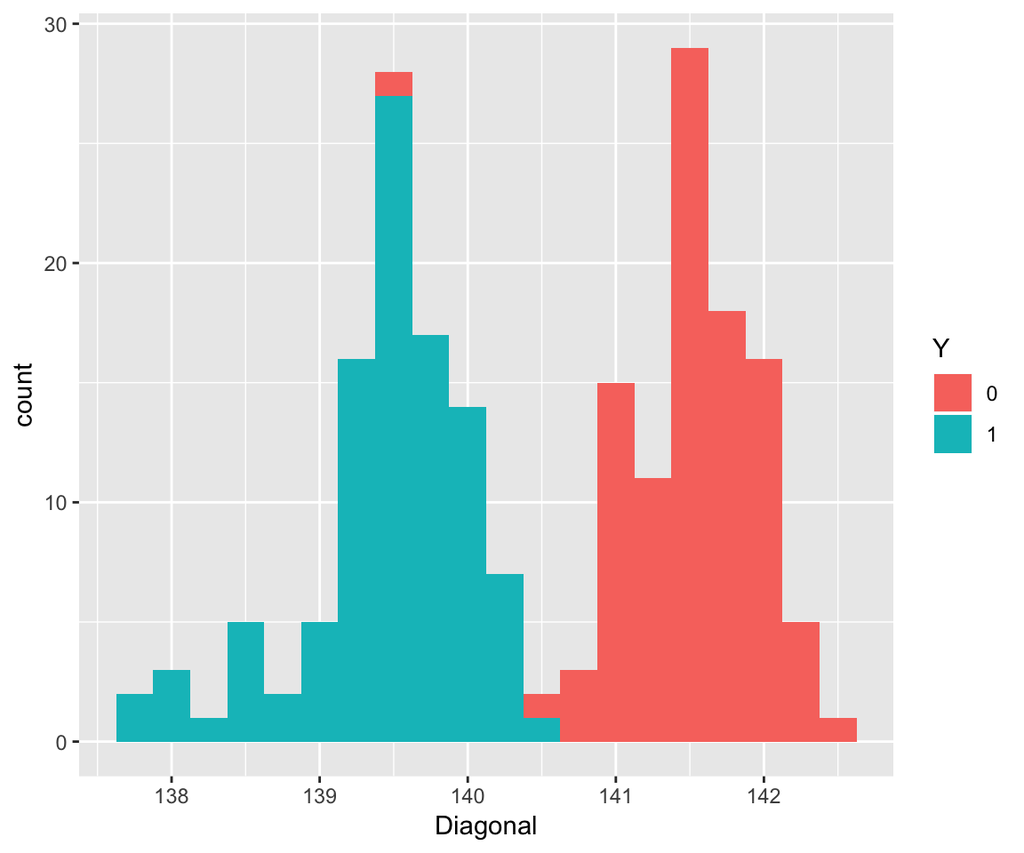

```r
ggplot(banknote, aes(x = Diagonal, fill = Y)) +
  geom_histogram(binwidth = 0.25)
```

On this histogram of the diagonal measurement of each banknote, we can see that the counterfeit notes tend to have a much lower measurement than genuine notes, aside from one genuine note that has a much lower diagnoal than the rest of the genuines.

6. Use the package `ggplot2` to draw a scatterplot of two (continuous) measurements, color by Y. Try to find a pair of measurements that allow you to separate perfectly between genuine and counterfeit banknotes.

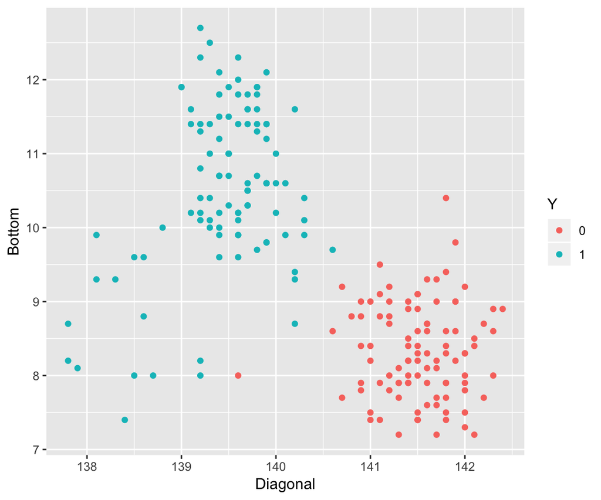

```r
ggplot(banknote, aes(x = Diagonal, y = Bottom, colour = Y)) +
  geom_point()
```

On this scatterplot of bottom measurements vs diagonal measurements, we can see that there is separation between the counterfeit and genuine notes. The genuine notes tend to have a higher diagonal measurement and lower bottom measurement than the counterfeit notes.

7. For each of the three figures above, write a two-three sentence summary, describing the
   1. **structure of the plot**: what type of plot is it? Which variables are mapped to x, to y, and to the (fill) color?
   2. **main message of the plot**: what is your main finding, i.e. what do you want viewers to learn from the plot?
   3. **additional message**: point out anomalies or outliers, if there are any.

Due date: the homework is due a week from now on Thursday.

For the submission: submit your solution in an R Markdown file and (just for insurance) submit the corresponding html/word file with it.